# ICL maximisation for discrete latent variable models

Etienne Côme

23 mai 2019

## Introduction

Model based clustering is a principled approach for clustering (Fraley and Raftery 2002), that has already proved to be very useful in a variety of context thanks to it’s capability of dealing with particular data structures. Such approaches encompasses to name a few: Gaussian Mixture Models (GMM), mixture of regression and graph clustering models like Stochastic Block Models (SBM). In their basic form such models assume that the observations $\{x_1,...x_N\}$ are drawn from a two step process, first a discrete latent variable is drawn using a multinomial distribution (with proportions $\pi$), then conditionally on the drawn cluster an observation is sampled using the cluster own distribution. More formally, this can be written as:

$$\begin{eqnarray}
\mathbf{z}_i|\pi&\sim& \mathcal{M}(1,\pi)\\
x_i|\mathbf{z}_{ik}=1,\theta_{k}&\sim& \mathcal{F}(\theta_{k}),
\end{eqnarray}$$

where the $\mathbf{z}_i\in\{0,1\}^K$ is the so-called latent variable encoding cluster membership. From a computational perspective there are two main way to deal with such type of models. From a frequentist perspective, if the main focus is in estimating the data distribution it’s natural to integrate out the latent variable and look for the $\theta$ that maximize the likelihood:

$$\begin{eqnarray}
L(\theta_1,...,\theta_K)=\prod_{i=1}^N\sum_{k=1}^{K}\pi_k f(x_i;\theta_k),
\end{eqnarray}$$
where $f$ is the density of the mixtures component distributions. Such functional forms are not easy to optimize but the well known EM algorithm (Dempster, Laird, and Rubin 1977) is a natural solution to this problem when the latent variable are independents given the observations. When this is not the case one may resorts to variational approximations (Jordan et al. 1999) to solve the optimization problem. These type of approaches converge to a local maximum of the likelihood and require the number of cluster to be fixed. When the number of groups $K$ is unknown, one classically try several values and resorts to model selection criteria like BIC and AIC (McLachlan and Peel 2000) to find the best fitting model given the data at hands. These solution leads typically to algorithms with complexity $\mathcal{O}(NK^2d)$ where $d$ is the number of features (for model selection and model fitting).

Always from a frequentist perspective when the main goal is to recovers the latent variable states one may keep them in the optimization problem and try to maximize the complete data likelihood with respect to both the latent variables states and the distributions parameters. This leads to the Classification EM algorithm (Celeux and Govaert 1992) which generalize the K-means algorithm (which corresponds to the special case of a mixture of spherical Gaussian with equal proportions). Such solution leads to algorithm with the same complexity as a classical EM even if they may converge more quickly. Such approaches also leave open the question of model selection (with respect to the number of mixture component).

From a Bayesian perspective a natural way to deals with finite mixture model come from MCMC sampling which can be used to sample both latent variables values and parameters according to the posterior distribution. In such setting, the mixture model is complemented with prior distributions over parameters $(\pi,\theta_1,...,\theta_k)$, which are often chosen to be conjugate. A Dirichlet distribution being used as prior for the latent variables. This leads to the following type of models:

$$\begin{eqnarray}
\pi&\sim& \mathcal{D}(\mathbf{\alpha})\\
\mathbf{z}_i|\pi&\sim& \mathcal{M}(1,\pi)\\
\theta_{k}&\sim& P(\mathbf{\beta})\\
x_i|\mathbf{z}_{ik}=1,\theta_k&\sim& \mathcal{F}(\theta_{k})
\end{eqnarray}$$

with $\mathcal{D}(\alpha)$ the Dirichlet distribution of parameter $\alpha$ and $P(\beta)$ a prior distribution for the $\theta$’s. Using Gibbs sampling (Diebolt and P. 1994) or variant one may obtain sample from the posterior distribution. However, sampling can be hard with difficulty to explore the different modes of the posterior distribution. Explotation of the posterior samples can also be challeging to perform due to the label switching problem (Diebolt and P. 1994,Stephens (2000)). Difficulties may for in retrieving the more plausible latent variable state (Rastelli and Friel 2018). For a more complete discussion of these different approaches and a complete state of the art on these problems see (Celeux, Fruewirth-Schnatter, and Robert 2018).

In between the frequentist and the Bayesian approaches several works introduced (at the begining for model selection purposes) the Integrated claffification likelihood (ICL), which correspond to the marginalisation of the model over it’s parameters leaving solely the data, the latent variables and the priors parameters:

$$\begin{eqnarray}
ICL(X,Z;\alpha,\beta) = \log(p(X,Z|\alpha,\beta)) &=& \log\left(\int_{\theta}\int_{\pi}p(x|z,\theta)p(\theta|\beta)p(z|\pi)p(\pi|\alpha)d\theta d\pi\right)\\
&=&\log\left(\int_{\pi}p(z|\pi)p(\pi|\alpha)d\pi\right)+\log\left(\int_{\theta}p(x|z,\theta)p(\theta|\beta)d\theta\right)
\end{eqnarray}$$
Approximate ICL criterion were first introduce and correspond to a BIC like approximation of this integral with improper and non informative prior. Note that ICL was originally proposed by Biernacki, Celeux and Govaert (Biernacki, Celeux, and Govaert 2000) for Gaussian mixture models. It was then adapted by Biernacki, Celeux and Govaert (Biernacki, Celeux, and Govaert 2010) to mixtures of multivariate multinomial distributions and to the SBM model by Daudin, Picard and Robin (Daudin, Picard, and Robin 2008).

As a motivating example for the proposed solution we simulate a random SBM graph with 1500 nodes and a hierarchical cluster structure with 3 big clusters each composed of 5 small clusters. The small clusters have an intra connectivty probability of 0.1 and a probability of connecting a node from the same of big cluster of 0.025. Eventually two random node are connected with a probability of 0.001. Fig 1. presents the result of a greedy opitmisation with a random starting partition with twenty clusters. The results of the proposed hybrid optimization algorithm and the results after reordoning the clusters with the regularisation path exatraction heuristic.

```r
N=1500
K=15
pi=rep(1/K,K)
lambda  = 0.1
lambda_o = 0.025
Ks=5
mu = bdiag(lapply(1:(K/Ks), function(k){matrix(lambda_o,Ks,Ks)+diag(rep(lambda,Ks))}))+0.001
sbm = rsbm(N,pi,mu)
```

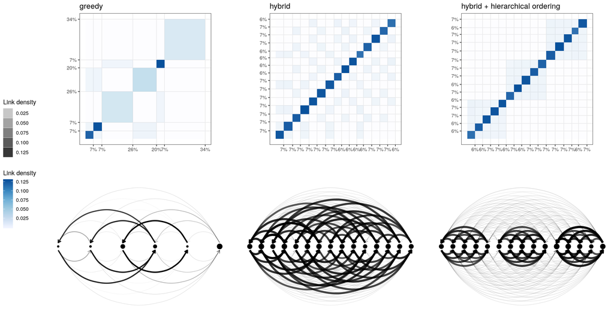

Motivating example of the proposed algorithm. Block matrix representation of the solutions (upper row) and cluster node link diagram (bottom row).

As clearly shown by this example greedy heuristic with random strating point suffers from under-fitting with only 6 clusters extracted among the 15 simulated. The hybrid algorithm did not suffer from under-fitting in this example and the hierachical ordering enable clear visualisation of the hierachical structure of this dataset.

This paper is organized as follow, first the ICL criterions for some mixture model are detailled, in particular in the graph clustering context where the partition apply to both the rows and colums of the data-matrix. Then, the proposed optimization strategy is described and tested in sereval simulated and real test cases and compared with possible alternatives. Eventualy, the heuristic to extract a regularization path over $\alpha$ is introduced and it’s interest in real situation demonstrated. Prior to some words on related works and concluding remarks.

### Models and criterions

#### Mixture of regression with gaussian mixture as special case

#### Stochastick block models and it’s degree corected version

### Optimization Algorithms

Current solution to optimize directly ICL type criterions are mainly based on greedy hill climbing algorithms (Côme and Latouche 2015,Bertoletti, Friel, and Rastelli (2015),Corneli, Latouche, and Rossi (2016),Wyse, Friel, and Latouche (2017),Zreik, Latouche, and Bouveyron (2017)). Starting from a carrefully chosen over-segmented initial partition (build using k-means for example), swap and eventually merge moved are appplied to increase the criterion. During the process clusters can die enabling model selection with respect to the number of cluster. These algorithms are quite easy to set up, computationaly attractive and give quite good results. The major drawback of this approach is it’s dependancy to the quality of the starting partition. When random initialization is used and the clustering structure is not easy to extract such algorithms may lead to under-fitting as demonsatred in the introductory example. To deal with this limitation, one potential path to investigate come from meta-heuristics which thanks to their more global nature could be a way to solve this problem. Following this idea we tried to mix the greedy local search heuristic already proposed with genetic algorithms.

```
parameters : size of the population (V), probability of mutation (pm), maximum number of generation (nb_max_generation)
Build a population [P^1,...,P^V] of initial solutions using greedy swap
while nb_generation < nb_max_generation
  add the best solution in the population to the new generation
  sample according to their rank (V - 1) pairs of solution in the population
  for each pairs (P1,P2) of partitions
    build the cross partition PN = P1 \time P2
    update PN using greedy merge
    if random number < pm
      sample a cluster of PN and split it randomly in two
    update PN using greedy swap
    add PN to the new generation
  replace the population by the new generation
  nb_generation ++
return the best solution found
```

#### Computational efficiency

While already efficient this first version was optimized from a computational perspective by tacking advantage of several features of the problem. In fact, from a complexity point of view the recombination and mutation process is performed in $\mathcal{O}(K^3)$ operations for the recombination (crossing followed by a greedy merge update) and $\mathcal{O}(NK^2)$ operations for the mutation and swap update. This is reasonable for relatively small values of $K$ but can be prohibtive for a larger number of cluster. To deal with problems involving a large number of cluster, several optimization were introduced. First crossing and greedy merge optimization were performed sequentialy for each cluster of one of the partition to cross. More formaly the crossing start with one of the parents and update the partition sequantialy by crossing it with a coarse version ofthe second parent were only onbe cluster is kept:

$$P^2_{i}=\left\{S^2_i,\bigcup_{j!=i}S^2_j\right\}$$
Furthermore after each of these partial crossing, the greedy merge update is performed but only between the newly created cluster. That is, cluster that were not split by the crossing operators are not considered any more in the merge process. This modification, lead to a complexity of $\mathcal{O}(K^2)$ for the recombination. With respect to the mutation and swap update a similar approach can be used, one may determine the clusters that have a common parent and allow swap movements only between them. This also alow to gain a factor$K$, leading to a complexity of $\mathcal{O}(NK)$. Eventually, as it’s common with genetic algorithm, these processes can easily be parallelized since they are indepenant for each new solution.

```
parameters : size of the population (V), probability of mutation (pm), maximum number of generation (nb_max_generation)
Build a population [P1,...,PV] of initial solutions using greedy swap using random starting partitions
while nb_generation < nb_max_generation
  add the best solution in the population to the new generation
  sample according to their rank (V - 1) pairs of solution in the population
  for each pairs (P1,$P2) of partitions
    PN = P1
    for each clusters i of P^2
      PN = PN \time P2_i
      update PN using greedy merge between the newly created cluster
    if random number < pm
      sample a cluster of PN and split it randomly in two
    determine all the pairs of cluster that have a common parents cluster either in P1 or P2
    update PN using greedy swap allowing only swap movements between the pairs of cluster with a common parent
    add PN to the new generation
  replace the population by the new generation
  nb_generation ++
return the best solution found
```

These modifications leads to an algorithm that is not dependant from an initialisation and still appplicable to large datasets.

#### Experiments

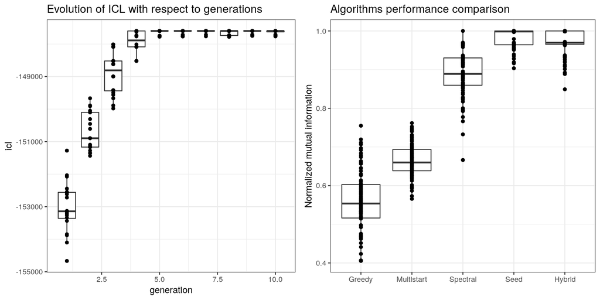

Evolution of the ICL criterion aliong the different generation build by the algorithm (left). comparison in term of NMI with the simulated clusters for several algorithm.

As a second simulation we tried a mixture of multinomial model. The simulation setup was as follow: 15 clusters with equal proportions were generated. The sample size was fixed to 500 and the number of possible outcomes for the multinomials to 100. The multinomial parameters were set such that for each cluster ten randomly chosen outcomes have a probability four time bigger than the others. Eventually the number of draw for each multinomial sample was set to 50. The simulation was performed one hundred time and for each generated datasets the solutions found by the the differents variants of the greedy heuristic, an EM algorithm (from the mixtools R package) with model selection performed with AIC, BIC and approximate ICL were recorded.

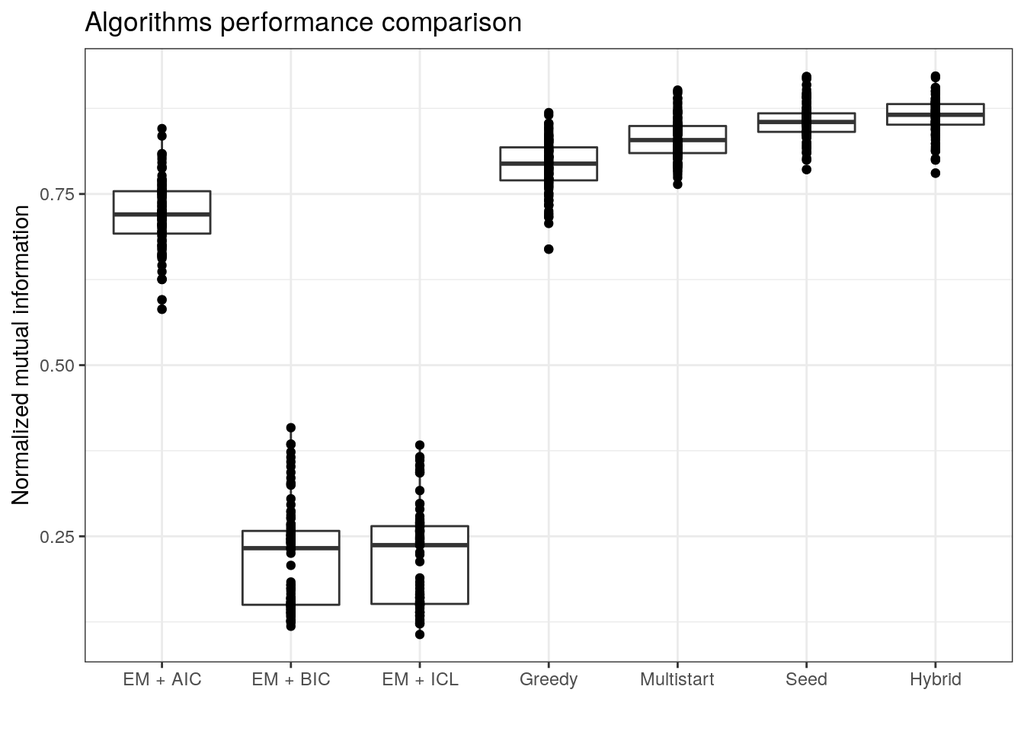

|  | 1 | 2 | 3 | 4 | 5 | 6 | 7 | 8 | 9 | 10 | 11 | 12 | 13 | 14 | 15 | 16 | 17 | 18 | 19 | 20 |
| --- | --- | --- | --- | --- | --- | --- | --- | --- | --- | --- | --- | --- | --- | --- | --- | --- | --- | --- | --- | --- |
| EM + BIC | 0 | 45 | 43 | 12 | 0 | 0 | 0 | 0 | 0 | 0 | 0 | 0 | 0 | 0 | 0 | 0 | 0 | 0 | 0 | 0 |
| EM + AIC | 0 | 0 | 0 | 0 | 0 | 0 | 0 | 0 | 0 | 0 | 4 | 5 | 19 | 14 | 17 | 15 | 16 | 4 | 5 | 1 |
| EM + ICL | 0 | 45 | 43 | 12 | 0 | 0 | 0 | 0 | 0 | 0 | 0 | 0 | 0 | 0 | 0 | 0 | 0 | 0 | 0 | 0 |
| Greedy | 0 | 0 | 0 | 0 | 0 | 0 | 0 | 0 | 0 | 0 | 0 | 0 | 10 | 33 | 37 | 17 | 2 | 1 | 0 | 0 |
| Multistart | 0 | 0 | 0 | 0 | 0 | 0 | 0 | 0 | 0 | 0 | 0 | 0 | 9 | 27 | 43 | 16 | 4 | 1 | 0 | 0 |
| Seed | 0 | 0 | 0 | 0 | 0 | 0 | 0 | 0 | 0 | 0 | 0 | 0 | 0 | 7 | 58 | 26 | 8 | 1 | 0 | 0 |
| Hybrid | 0 | 0 | 0 | 0 | 0 | 0 | 0 | 0 | 0 | 0 | 0 | 0 | 2 | 9 | 76 | 13 | 0 | 0 | 0 | 0 |

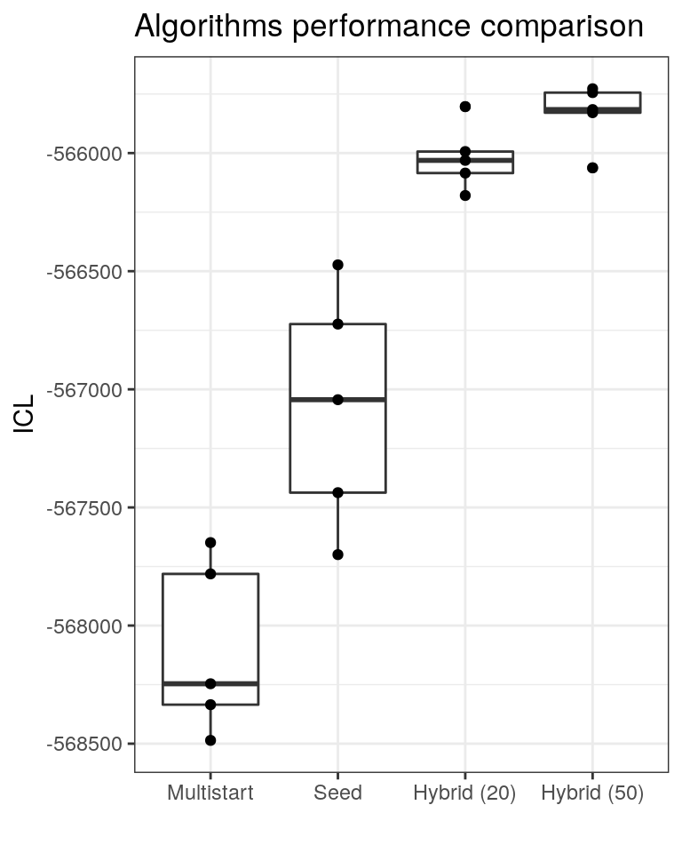

## Regularisation path and hierarchical clustering

### Real data

```r
data("Blogs")
fit_blogs = greed(Blogs$X,model=new("dcsbm"))
data("Books")
fit_books = greed(Books$X,model=new("dcsbm"))
data("Football")
fit_foot = greed(Football$X,model=new("dcsbm"))
data("Jazz")
fit_jazz = greed(Jazz,model=new("dcsbm"))
```

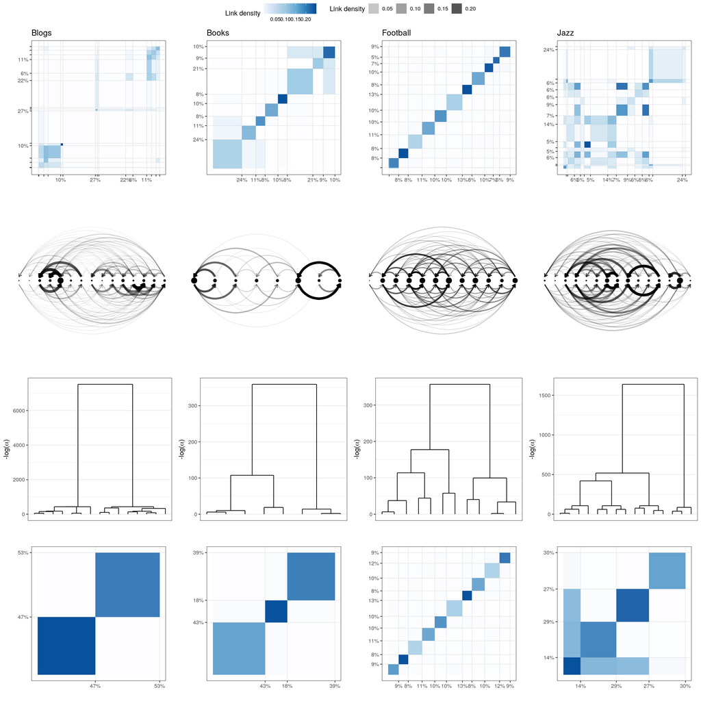

## Related works and conclusions

## References

Bertoletti, Marco, Nial Friel, and Riccardo Rastelli. 2015. “Choosing the Number of Clusters in a Finite Mixture Model Using an Exact Integrated Completed Likelihood Criterion.” *METRON* 73 (2): 177–99. doi:10.1007/s40300-015-0064-5.

Biernacki, Christophe, Gilles Celeux, and Gerard Govaert. 2000. “Assessing a Mixture Model for Clustering with the Integrated Completed Likelihood.” *IEEE Transaction on Pattern Analysis and Machine Intelligence* 7: 719–25.

———. 2010. “Exact and Monte Carlo Calculations of Integrated Likelihoods for the Latent Class Model.” *Journal of Statistical Planning and Inference* 140: 2991–3002.

Celeux, Gilles, and Gerard Govaert. 1992. “A Classification Em Algorithm for Clustering and Two Stochastic Versions.” *Computational Statistics & Data Analysis* 14 (3): 315–32. https://EconPapers.repec.org/RePEc:eee:csdana:v:14:y:1992:i:3:p:315-332.

Celeux, Gilles, Sylvia Fruewirth-Schnatter, and Christian P. Robert. 2018. “Model Selection for Mixture Models - Perspectives and Strategies.” *arXiv E-Prints*, December, arXiv:1812.09885.

Corneli, Marco, Pierre Latouche, and Fabrice Rossi. 2016. “Exact Icl Maximization in a Non-Stationary Temporal Extension of the Stochastic Block Model for Dynamic Networks.” *Neurocomputing* 192: 81–91. doi:https://doi.org/10.1016/j.neucom.2016.02.031.

Côme, Etienne, and Pierre Latouche. 2015. “Model Selection and Clustering in Stochastic Block Models Based on the Exact Integrated Complete Data Likelihood.” *Statistical Modelling* 15 (6): 564–89. doi:10.1177/1471082X15577017.

Daudin, J., F. Picard, and S. Robin. 2008. “A Mixture Model for Random Graph.” *Statistics and Computing* 18: 1–36.

Dempster, A. P., N. M. Laird, and D. B. Rubin. 1977. “Maximum Likelihood from Incomplete Data via the Em Algorithm.” *Journal of the Royal Statistical Society. Series B (Methodological)* 39 (1). [Royal Statistical Society, Wiley]: 1–38. http://www.jstor.org/stable/2984875.

Diebolt, J., and Robert C. P. 1994. “Estimation of Finite Mixture Distributions Through Bayesian Sampling.” *Journal of the Royal Statistical Society B* 56: 363–75.

Fraley, Chris, and Adrian E Raftery. 2002. “Model-Based Clustering, Discriminant Analysis, and Density Estimation.” *Journal of the American Statistical Association* 97 (458). Taylor & Francis: 611–31. doi:10.1198/016214502760047131.

Jordan, Michael I., Zoubin Ghahramani, Tommi S. Jaakkola, and Lawrence K. Saul. 1999. “An Introduction to Variational Methods for Graphical Models.” *Mach. Learn.* 37 (2). Hingham, MA, USA: Kluwer Academic Publishers: 183–233. doi:10.1023/A:1007665907178.

McLachlan, Geoffrey, and David Peel. 2000. *Finite Mixture Models*. John Wiley & Sons, Inc. doi:10.1002/0471721182.

Rastelli, Riccardo, and Nial Friel. 2018. “Optimal Bayesian Estimators for Latent Variable Cluster Models.” *Statistics and Computing* 28 (6): 1169–86. doi:10.1007/s11222-017-9786-y.

Stephens, Matthew. 2000. “Dealing with Label Switching in Mixture Models.” *Journal of the Royal Statistical Society B* 62 (4): 795–809.

Wyse, Jason, Nial Friel, and Pierre Latouche. 2017. “Inferring Structure in Bipartite Networks Using the Latent Blockmodel and Exact Icl.” *Network Science* 5 (1). Cambridge University Press: 45–69. doi:10.1017/nws.2016.25.

Zreik, Rawya, Pierre Latouche, and Charles Bouveyron. 2017. “The Dynamic Random Subgraph Model for the Clustering of Evolving Networks.” *Computational Statistics* 32 (2): 501–33. doi:10.1007/s00180-016-0655-5.